# Part I - (Ford GoBike Data Visual Exploration)

## by Joshua Nnatus

### Table of content

- Introduction
- Preliminary Wrangling
- Data Cleaning
- Univariate Exploration
- Bivariate Exploration
- Multivariate Exploration
- Conclusions

## Introduction

> The Bay Area's bikeshare program is called Ford GoBike was introduced in 2013, and have featured thousands of bikes and across 70 stations around San Francisco. The Ford GoBike uses a fleet of strong, durable bikes that are secured into a system of docking stations spread out over the city. This document explores individual rides made in a bike-sharing system covering the greater San Francisco Bay area. This dataset is the ford Bikeshare for the month of Feburary 2019.

> `Source:` [Ford GoBike System Data](https://www.google.com/url?q=https%3A%2F%2Fvideo.udacity-data.com%2Ftopher%2F2020%2FOctober%2F5f91cf38_201902-fordgobike-tripdata%2F201902-fordgobike-tripdata.csv&sa=D&source=docs)

> `NOTE: I wanted to get the entire dataset for the entire year of forebike but the link is broken` [Systems Data Page](http://www.melbournebikeshare.com.au/stationmap/data)

## Preliminary Wrangling

```python
# import all packages and set plots to be embedded inline
import numpy as np
import pandas as pd
import matplotlib.pyplot as plt
import seaborn as sb

%matplotlib inline
```

```python
bike= pd.read_csv("201902-fordgobike-tripdata.csv")
```

```python
# Visually assessing the data for issues of tidiness and/or quality issue
bike.head()
```

|  | duration_sec | start_time | end_time | start_station_id | start_station_name | start_station_latitude | start_station_longitude | end_station_id | end_station_name | end_station_latitude | end_station_longitude | bike_id | user_type | member_birth_year | member_gender | bike_share_for_all_trip |
| --- | --- | --- | --- | --- | --- | --- | --- | --- | --- | --- | --- | --- | --- | --- | --- | --- |
| 0 | 52185 | 2019-02-28 17:32:10.1450 | 2019-03-01 08:01:55.9750 | 21.0 | Montgomery St BART Station (Market St at 2nd St) | 37.789625 | -122.400811 | 13.0 | Commercial St at Montgomery St | 37.794231 | -122.402923 | 4902 | Customer | 1984.0 | Male | No |
| 1 | 42521 | 2019-02-28 18:53:21.7890 | 2019-03-01 06:42:03.0560 | 23.0 | The Embarcadero at Steuart St | 37.791464 | -122.391034 | 81.0 | Berry St at 4th St | 37.775880 | -122.393170 | 2535 | Customer | NaN | NaN | No |
| 2 | 61854 | 2019-02-28 12:13:13.2180 | 2019-03-01 05:24:08.1460 | 86.0 | Market St at Dolores St | 37.769305 | -122.426826 | 3.0 | Powell St BART Station (Market St at 4th St) | 37.786375 | -122.404904 | 5905 | Customer | 1972.0 | Male | No |
| 3 | 36490 | 2019-02-28 17:54:26.0100 | 2019-03-01 04:02:36.8420 | 375.0 | Grove St at Masonic Ave | 37.774836 | -122.446546 | 70.0 | Central Ave at Fell St | 37.773311 | -122.444293 | 6638 | Subscriber | 1989.0 | Other | No |
| 4 | 1585 | 2019-02-28 23:54:18.5490 | 2019-03-01 00:20:44.0740 | 7.0 | Frank H Ogawa Plaza | 37.804562 | -122.271738 | 222.0 | 10th Ave at E 15th St | 37.792714 | -122.248780 | 4898 | Subscriber | 1974.0 | Male | Yes |

> - There are missing values in member_birth years
> - The member_birth_year is having a decimal value

```python
# checking the data type and properties of each series in the dataframe
bike.info()
```

```
<class 'pandas.core.frame.DataFrame'>
RangeIndex: 183412 entries, 0 to 183411
Data columns (total 16 columns):
 #   Column                   Non-Null Count   Dtype
---  ------                   --------------   -----
 0   duration_sec             183412 non-null  int64
 1   start_time               183412 non-null  object
 2   end_time                 183412 non-null  object
 3   start_station_id         183215 non-null  float64
 4   start_station_name       183215 non-null  object
 5   start_station_latitude   183412 non-null  float64
 6   start_station_longitude  183412 non-null  float64
 7   end_station_id           183215 non-null  float64
 8   end_station_name         183215 non-null  object
 9   end_station_latitude     183412 non-null  float64
 10  end_station_longitude    183412 non-null  float64
 11  bike_id                  183412 non-null  int64
 12  user_type                183412 non-null  object
 13  member_birth_year        175147 non-null  float64
 14  member_gender            175147 non-null  object
 15  bike_share_for_all_trip  183412 non-null  object
dtypes: float64(7), int64(2), object(7)
memory usage: 22.4+ MB
```

> - Start_time, and end_time should be datatime datatype
> - bike_share_for_all_trip, User_type and member_gender should be catergory datatype
> - Missing values in member_gender, member_birth_year, end_station_id, start_station_name, start_station_id and end_station_name
> - member_birth_year has a wrong data format
> - start_station_id and end_station_id has wrong data type

```python
# sampling data in the dataframe to see if there is any issues

bike.sample(10)
```

|  | duration_sec | start_time | end_time | start_station_id | start_station_name | start_station_latitude | start_station_longitude | end_station_id | end_station_name | end_station_latitude | end_station_longitude | bike_id | user_type | member_birth_year | member_gender | bike_share_for_all_trip |
| --- | --- | --- | --- | --- | --- | --- | --- | --- | --- | --- | --- | --- | --- | --- | --- | --- |
| 147061 | 450 | 2019-02-07 08:14:18.0290 | 2019-02-07 08:21:49.0000 | 27.0 | Beale St at Harrison St | 37.788059 | -122.391865 | 20.0 | Mechanics Monument Plaza (Market St at Bush St) | 37.791300 | -122.399051 | 3451 | Subscriber | 1988.0 | Female | No |
| 19595 | 128 | 2019-02-26 16:37:46.6200 | 2019-02-26 16:39:55.1370 | 267.0 | Derby St at College Ave | 37.861804 | -122.253569 | 269.0 | Telegraph Ave at Carleton St | 37.862320 | -122.258801 | 6630 | Subscriber | 1989.0 | Male | Yes |
| 110000 | 981 | 2019-02-12 18:14:41.4380 | 2019-02-12 18:31:02.5860 | 5.0 | Powell St BART Station (Market St at 5th St) | 37.783899 | -122.408445 | 380.0 | Masonic Ave at Turk St | 37.779047 | -122.447291 | 4319 | Subscriber | NaN | NaN | No |
| 127963 | 369 | 2019-02-10 14:28:42.4630 | 2019-02-10 14:34:51.9540 | 257.0 | Fifth St at Delaware St | 37.870407 | -122.299676 | 262.0 | West St at University Ave | 37.869967 | -122.286533 | 4668 | Subscriber | 1997.0 | Female | Yes |
| 99095 | 356 | 2019-02-14 21:30:42.4920 | 2019-02-14 21:36:39.2650 | 181.0 | Grand Ave at Webster St | 37.811377 | -122.265192 | 197.0 | El Embarcadero at Grand Ave | 37.808848 | -122.249680 | 3703 | Subscriber | 1986.0 | Male | No |
| 53926 | 72 | 2019-02-21 14:25:35.6750 | 2019-02-21 14:26:48.4070 | 243.0 | Bancroft Way at College Ave | 37.869360 | -122.254337 | 239.0 | Bancroft Way at Telegraph Ave | 37.868813 | -122.258764 | 5604 | Subscriber | 1994.0 | Male | No |
| 51474 | 1199 | 2019-02-21 17:48:32.5300 | 2019-02-21 18:08:32.0800 | 30.0 | San Francisco Caltrain (Townsend St at 4th St) | 37.776598 | -122.395282 | 55.0 | Webster St at Grove St | 37.777053 | -122.429558 | 6129 | Subscriber | 1986.0 | Female | No |
| 178934 | 171 | 2019-02-01 16:03:22.9200 | 2019-02-01 16:06:13.9400 | 364.0 | China Basin St at 3rd St | 37.772000 | -122.389970 | 81.0 | Berry St at 4th St | 37.775880 | -122.393170 | 532 | Subscriber | 1982.0 | Male | No |
| 108640 | 320 | 2019-02-13 07:11:04.6970 | 2019-02-13 07:16:24.8180 | 47.0 | 4th St at Harrison St | 37.780955 | -122.399749 | 90.0 | Townsend St at 7th St | 37.771058 | -122.402717 | 4372 | Subscriber | 1971.0 | Male | No |
| 157560 | 103 | 2019-02-05 21:35:33.8790 | 2019-02-05 21:37:16.9810 | 24.0 | Spear St at Folsom St | 37.789677 | -122.390428 | 23.0 | The Embarcadero at Steuart St | 37.791464 | -122.391034 | 3226 | Subscriber | 1980.0 | Male | No |

```python
# a peak at the dimension of the dataframe
bike.shape
```

```
(183412, 16)
```

> - The dataframe has 183412 rows and 16 columns (features)

```python
# Check if there is any duplicate in the dataframe
bike.duplicated().sum()
```

```
0
```

> - There is no duplicate data

```python
bike.describe()
```

|  | duration_sec | start_station_id | start_station_latitude | start_station_longitude | end_station_id | end_station_latitude | end_station_longitude | bike_id | member_birth_year |
| --- | --- | --- | --- | --- | --- | --- | --- | --- | --- |
| count | 183412.000000 | 183215.000000 | 183412.000000 | 183412.000000 | 183215.000000 | 183412.000000 | 183412.000000 | 183412.000000 | 175147.000000 |
| mean | 726.078435 | 138.590427 | 37.771223 | -122.352664 | 136.249123 | 37.771427 | -122.352250 | 4472.906375 | 1984.806437 |
| std | 1794.389780 | 111.778864 | 0.099581 | 0.117097 | 111.515131 | 0.099490 | 0.116673 | 1664.383394 | 10.116689 |
| min | 61.000000 | 3.000000 | 37.317298 | -122.453704 | 3.000000 | 37.317298 | -122.453704 | 11.000000 | 1878.000000 |
| 25% | 325.000000 | 47.000000 | 37.770083 | -122.412408 | 44.000000 | 37.770407 | -122.411726 | 3777.000000 | 1980.000000 |
| 50% | 514.000000 | 104.000000 | 37.780760 | -122.398285 | 100.000000 | 37.781010 | -122.398279 | 4958.000000 | 1987.000000 |
| 75% | 796.000000 | 239.000000 | 37.797280 | -122.286533 | 235.000000 | 37.797320 | -122.288045 | 5502.000000 | 1992.000000 |
| max | 85444.000000 | 398.000000 | 37.880222 | -121.874119 | 398.000000 | 37.880222 | -121.874119 | 6645.000000 | 2001.000000 |

> - There appears to be an outlier in the duration_sec with the maximum duration 85444 while the 75% and 50% quartile had less than 1000, `"This would be explored more using visuals"`

```python
# Check the unique values in bike_share_for_all_trip
bike.bike_share_for_all_trip.unique()
```

```
array(['No', 'Yes'], dtype=object)
```

```python
# Check the unique values in user_type
bike.user_type.unique()
```

```
array(['Customer', 'Subscriber'], dtype=object)
```

```python
# Check the unique vlaues in the member_gender
bike.member_gender.unique()
```

```
array(['Male', nan, 'Other', 'Female'], dtype=object)
```

```python
# Checked for empty "NaN" and/or "None" cells

bike.isna().sum()
```

```
duration_sec                  0
start_time                    0
end_time                      0
start_station_id            197
start_station_name          197
start_station_latitude        0
start_station_longitude       0
end_station_id              197
end_station_name            197
end_station_latitude          0
end_station_longitude         0
bike_id                       0
user_type                     0
member_birth_year          8265
member_gender              8265
bike_share_for_all_trip       0
dtype: int64
```

> - There are empty cell in start_station_id, start_station_name, end_station_id, end_station_name, member_birth_year, and member_gender

### Quality issues

> 1. Missing values in member_gender, member_birth_year, end_station_id, start_station_name, start_station_id and end_station_name
> 2. Start_time, and end_time should be datatime datatype
> 3. bike_share_for_all_trip, User_type and member_gender should be catergory datatype
> 4. The member_birth_year, start_station_id and end_station_id is having a decimal value and has a wrong data type

### Tidiness issues

> There are no tidiness issues:\ Every column is a variable,\ Every row is an observation,\ Every cell is a single value and every rows and columns forms a table
> 1. But I want to create a feature age and see if we can further turn it to a categorical feature of young and old or more
> 2. Distance covered for each member
> 3. Create a column for Start month, end month, day of the week, minutes and hour of trip duration

## Cleaning

```python
# Make copies of original pieces of data
bike_clean = bike.copy()
```

### Quality issues

#### Issues 1

#### Define

Missing values in member_gender, member_birth_year, end_station_id, start_station_name, start_station_id and end_station_name

#### Code

```python
# Using the dropna to remove missing values and `inplace=True` to keep it in the dataframe
bike_clean.dropna(inplace=True)
```

#### Test

```python
bike_clean.isna().sum()
```

```
duration_sec               0
start_time                 0
end_time                   0
start_station_id           0
start_station_name         0
start_station_latitude     0
start_station_longitude    0
end_station_id             0
end_station_name           0
end_station_latitude       0
end_station_longitude      0
bike_id                    0
user_type                  0
member_birth_year          0
member_gender              0
bike_share_for_all_trip    0
dtype: int64
```

```python
bike_clean.shape
```

```
(174952, 16)
```

#### Issues 2

#### Define

Start_time, and end_time should be datatime datatype, would need to convert object to datetime datetype by using the `'to_datetime'` method

#### Code

```python
# Use to_datetime converts objects to datatime datatype
bike_clean.start_time = pd.to_datetime(bike_clean.start_time)
bike_clean.end_time = pd.to_datetime(bike_clean.end_time)
```

#### Test

```python
# checking the start_time and end_time have been properly converted
bike_clean[["start_time", "end_time"]].info()
```

```
<class 'pandas.core.frame.DataFrame'>
Int64Index: 174952 entries, 0 to 183411
Data columns (total 2 columns):
 #   Column      Non-Null Count   Dtype
---  ------      --------------   -----
 0   start_time  174952 non-null  datetime64[ns]
 1   end_time    174952 non-null  datetime64[ns]
dtypes: datetime64[ns](2)
memory usage: 4.0 MB
```

#### Issues 3

#### Define

bike_share_for_all_trip, User_type and member_gender should be `"catergory datatype"`, will change `"no"` and `"yes"` in bike_share_for_all_trip to catergory, change `"Customer"` and `"Subscriber"` in user_type to catergories, and change `"male"`, `"female"` and `"other"` in member_gender to categories

```python
# coverting datatype to catergories, will not use other since they are not quantifiable
# In this dataset yes is not greater than no nor, male greater than female etc

bike_clean.bike_share_for_all_trip = bike_clean.bike_share_for_all_trip.astype('category')
bike_clean.user_type = bike_clean.user_type.astype('category')
bike_clean.member_gender = bike_clean.member_gender.astype('category')
```

#### Code

```python
bike_clean[["bike_share_for_all_trip", "member_gender", "user_type"]].info()
```

```
<class 'pandas.core.frame.DataFrame'>
Int64Index: 174952 entries, 0 to 183411
Data columns (total 3 columns):
 #   Column                   Non-Null Count   Dtype
---  ------                   --------------   -----
 0   bike_share_for_all_trip  174952 non-null  category
 1   member_gender            174952 non-null  category
 2   user_type                174952 non-null  category
dtypes: category(3)
memory usage: 1.8 MB
```

#### Issue 4

#### Define

The member_birth_year, start_station_id and end_station_id is having a decimal value and showing to be a floating point number. would need to convert the data type to int

#### Code

```python
# Converting float to int
bike_clean.member_birth_year = bike_clean.member_birth_year.astype('int')
bike_clean.start_station_id = bike_clean.start_station_id.astype('int')
bike_clean.end_station_id = bike_clean.end_station_id.astype('int')
```

#### Test

```python
bike_clean[["member_birth_year", "start_station_id", "end_station_id"]].info()
```

```
<class 'pandas.core.frame.DataFrame'>
Int64Index: 174952 entries, 0 to 183411
Data columns (total 3 columns):
 #   Column             Non-Null Count   Dtype
---  ------             --------------   -----
 0   member_birth_year  174952 non-null  int32
 1   start_station_id   174952 non-null  int32
 2   end_station_id     174952 non-null  int32
dtypes: int32(3)
memory usage: 3.3 MB
```

#### Issue 1

#### Define

There is need for an age feature, it hard to do a mental calculation looking at the birth years of the users, hence a need for age feature

#### Code

```python
# since the data only provides us with the birth year of each memeber
# I will just substract the birth year from the current year for which this analysis is doen
# and for reproducibility I won't just use the current year but a function that can input current year
# regardless of what year the code is ran, so the ages are updated,
# so I use the datetime.now to get the extact date
from datetime import datetime as dt

def age(born):
    today = dt.now().year
    return today -born
```

```python
bike_clean["member_age"] = age(bike_clean["member_birth_year"])
```

#### Test

```python
bike_clean.info()
```

```
<class 'pandas.core.frame.DataFrame'>
Int64Index: 174952 entries, 0 to 183411
Data columns (total 17 columns):
 #   Column                   Non-Null Count   Dtype
---  ------                   --------------   -----
 0   duration_sec             174952 non-null  int64
 1   start_time               174952 non-null  datetime64[ns]
 2   end_time                 174952 non-null  datetime64[ns]
 3   start_station_id         174952 non-null  int32
 4   start_station_name       174952 non-null  object
 5   start_station_latitude   174952 non-null  float64
 6   start_station_longitude  174952 non-null  float64
 7   end_station_id           174952 non-null  int32
 8   end_station_name         174952 non-null  object
 9   end_station_latitude     174952 non-null  float64
 10  end_station_longitude    174952 non-null  float64
 11  bike_id                  174952 non-null  int64
 12  user_type                174952 non-null  category
 13  member_birth_year        174952 non-null  int32
 14  member_gender            174952 non-null  category
 15  bike_share_for_all_trip  174952 non-null  category
 16  member_age               174952 non-null  int32
dtypes: category(3), datetime64[ns](2), float64(4), int32(4), int64(2), object(2)
memory usage: 17.9+ MB
```

```python
bike_clean.sample(10)
```

|  | duration_sec | start_time | end_time | start_station_id | start_station_name | start_station_latitude | start_station_longitude | end_station_id | end_station_name | end_station_latitude | end_station_longitude | bike_id | user_type | member_birth_year | member_gender | bike_share_for_all_trip | member_age |
| --- | --- | --- | --- | --- | --- | --- | --- | --- | --- | --- | --- | --- | --- | --- | --- | --- | --- |
| 13619 | 566 | 2019-02-27 15:21:45.322 | 2019-02-27 15:31:11.875 | 130 | 22nd St Caltrain Station | 37.757288 | -122.392051 | 81 | Berry St at 4th St | 37.775880 | -122.393170 | 4812 | Subscriber | 1989 | Male | No | 33 |
| 86608 | 611 | 2019-02-17 12:22:25.001 | 2019-02-17 12:32:36.962 | 364 | China Basin St at 3rd St | 37.772000 | -122.389970 | 23 | The Embarcadero at Steuart St | 37.791464 | -122.391034 | 5518 | Subscriber | 1992 | Female | No | 30 |
| 175992 | 1645 | 2019-02-02 12:28:58.370 | 2019-02-02 12:56:23.782 | 216 | San Pablo Ave at 27th St | 37.817827 | -122.275698 | 220 | San Pablo Ave at MLK Jr Way | 37.811351 | -122.273422 | 4622 | Subscriber | 1966 | Male | No | 56 |
| 182021 | 495 | 2019-02-01 08:39:31.830 | 2019-02-01 08:47:47.143 | 212 | Mosswood Park | 37.824893 | -122.260437 | 183 | Telegraph Ave at 19th St | 37.808702 | -122.269927 | 480 | Subscriber | 1990 | Male | No | 32 |
| 101049 | 153 | 2019-02-14 17:56:22.722 | 2019-02-14 17:58:56.047 | 182 | 19th Street BART Station | 37.809013 | -122.268247 | 180 | Telegraph Ave at 23rd St | 37.812678 | -122.268773 | 6615 | Subscriber | 1988 | Male | No | 34 |
| 91546 | 220 | 2019-02-16 05:51:52.179 | 2019-02-16 05:55:32.618 | 34 | Father Alfred E Boeddeker Park | 37.783988 | -122.412408 | 3 | Powell St BART Station (Market St at 4th St) | 37.786375 | -122.404904 | 3225 | Customer | 1976 | Male | No | 46 |
| 131847 | 239 | 2019-02-09 10:44:52.817 | 2019-02-09 10:48:52.456 | 136 | 23rd St at San Bruno Ave | 37.754436 | -122.404364 | 129 | Harrison St at 20th St | 37.758862 | -122.412544 | 4648 | Customer | 1997 | Male | No | 25 |
| 93068 | 460 | 2019-02-15 18:03:33.498 | 2019-02-15 18:11:14.415 | 338 | 13th St at Franklin St | 37.803189 | -122.270579 | 200 | 2nd Ave at E 18th St | 37.800214 | -122.253810 | 2099 | Subscriber | 1992 | Male | No | 30 |
| 66617 | 932 | 2019-02-20 08:29:23.725 | 2019-02-20 08:44:55.772 | 84 | Duboce Park | 37.769200 | -122.433812 | 30 | San Francisco Caltrain (Townsend St at 4th St) | 37.776598 | -122.395282 | 6070 | Subscriber | 1994 | Male | No | 28 |
| 139003 | 318 | 2019-02-07 23:25:19.820 | 2019-02-07 23:30:38.739 | 190 | West St at 40th St | 37.830223 | -122.270950 | 189 | Genoa St at 55th St | 37.839649 | -122.271756 | 1945 | Subscriber | 1975 | Male | No | 47 |

```python
bike_clean.member_age.describe()
```

```
count    174952.000000
mean         37.196865
std          10.118731
min          21.000000
25%          30.000000
50%          35.000000
75%          42.000000
max         144.000000
Name: member_age, dtype: float64
```

```python
# Lets see the 99% of bike riders age
bike_clean.member_age.describe(percentiles = [.99])
```

```
count    174952.000000
mean         37.196865
std          10.118731
min          21.000000
50%          35.000000
99%          67.000000
max         144.000000
Name: member_age, dtype: float64
```

> - There appears to be an outlier in the age a 144 years old member `It is next to impossible to have a 144 years old person bike a bike`
> - According to the guinness world records [LYNNEA SALVO](https://www.guinnessworldrecords.com/world-records/590324-oldest-person-to-cross-america-by-bicycle-n-s-female) at the age of 72, so I will limit the age to 72 and remove age values higher than 72
> - Although the 99 percent age is `"67"` I will like to use the guinness world record limit of `"72"`, just incase the ages increase next year

```python
bike_clean = bike_clean.query("member_age <= 72")
```

```python
bike_clean.info()
```

```
<class 'pandas.core.frame.DataFrame'>
Int64Index: 174278 entries, 0 to 183411
Data columns (total 17 columns):
 #   Column                   Non-Null Count   Dtype
---  ------                   --------------   -----
 0   duration_sec             174278 non-null  int64
 1   start_time               174278 non-null  datetime64[ns]
 2   end_time                 174278 non-null  datetime64[ns]
 3   start_station_id         174278 non-null  int32
 4   start_station_name       174278 non-null  object
 5   start_station_latitude   174278 non-null  float64
 6   start_station_longitude  174278 non-null  float64
 7   end_station_id           174278 non-null  int32
 8   end_station_name         174278 non-null  object
 9   end_station_latitude     174278 non-null  float64
 10  end_station_longitude    174278 non-null  float64
 11  bike_id                  174278 non-null  int64
 12  user_type                174278 non-null  category
 13  member_birth_year        174278 non-null  int32
 14  member_gender            174278 non-null  category
 15  bike_share_for_all_trip  174278 non-null  category
 16  member_age               174278 non-null  int32
dtypes: category(3), datetime64[ns](2), float64(4), int32(4), int64(2), object(2)
memory usage: 17.8+ MB
```

```python
bike_clean.member_age.describe()
```

```
count    174278.000000
mean         37.018448
std           9.679385
min          21.000000
25%          30.000000
50%          35.000000
75%          42.000000
max          72.000000
Name: member_age, dtype: float64
```

#### Issue 2

#### Define

The lattitude and longitude are great features but at and instance it can't tell tell the distance covered expecct one starts does a calculation, here I would use the longitude and latitude to get the distance covered for each member

> - Reference: https://stackoverflow.com/questions/40452759/pandas-latitude-longitude-to-distance-between-successive-rows https://stackoverflow.com/questions/19412462/getting-distance-between-two-points-based-on-latitude-longitude

#### Code

```python
# Will be using the math radians, sin, cos, sqrt and atan2
from math import radians, sin, cos, sqrt, atan2

def distance(start, end):

# The approximate earth radius, 6371 is in kilometers
    lat1, long1 = start
    lat2, long2 = end
    radius = 6371

    dlat = radians(lat2 - lat1)
    dlong = radians(long2 - long1)

    a = (sin(dlat / 2) * sin(dlat / 2) + cos(radians(lat1)) * cos(radians(lat2)) * sin(dlong / 2) * sin(dlong / 2))
    c = 2 * atan2(sqrt(a), sqrt(1 - a))
    distance = radius * c

    # Round up the values to two decimal places
    return round(distance, 2)
```

```python
bike_clean['distance_km'] = bike_clean.apply(lambda x: distance((x['start_station_latitude'], x['start_station_longitude']),
                                                            (x['end_station_latitude'], x['end_station_longitude'])),
                                         axis=1)
```

#### Test

```python
bike_clean.head()
```

|  | duration_sec | start_time | end_time | start_station_id | start_station_name | start_station_latitude | start_station_longitude | end_station_id | end_station_name | end_station_latitude | end_station_longitude | bike_id | user_type | member_birth_year | member_gender | bike_share_for_all_trip | member_age | distance_km |
| --- | --- | --- | --- | --- | --- | --- | --- | --- | --- | --- | --- | --- | --- | --- | --- | --- | --- | --- |
| 0 | 52185 | 2019-02-28 17:32:10.145 | 2019-03-01 08:01:55.975 | 21 | Montgomery St BART Station (Market St at 2nd St) | 37.789625 | -122.400811 | 13 | Commercial St at Montgomery St | 37.794231 | -122.402923 | 4902 | Customer | 1984 | Male | No | 38 | 0.54 |
| 2 | 61854 | 2019-02-28 12:13:13.218 | 2019-03-01 05:24:08.146 | 86 | Market St at Dolores St | 37.769305 | -122.426826 | 3 | Powell St BART Station (Market St at 4th St) | 37.786375 | -122.404904 | 5905 | Customer | 1972 | Male | No | 50 | 2.70 |
| 3 | 36490 | 2019-02-28 17:54:26.010 | 2019-03-01 04:02:36.842 | 375 | Grove St at Masonic Ave | 37.774836 | -122.446546 | 70 | Central Ave at Fell St | 37.773311 | -122.444293 | 6638 | Subscriber | 1989 | Other | No | 33 | 0.26 |
| 4 | 1585 | 2019-02-28 23:54:18.549 | 2019-03-01 00:20:44.074 | 7 | Frank H Ogawa Plaza | 37.804562 | -122.271738 | 222 | 10th Ave at E 15th St | 37.792714 | -122.248780 | 4898 | Subscriber | 1974 | Male | Yes | 48 | 2.41 |
| 5 | 1793 | 2019-02-28 23:49:58.632 | 2019-03-01 00:19:51.760 | 93 | 4th St at Mission Bay Blvd S | 37.770407 | -122.391198 | 323 | Broadway at Kearny | 37.798014 | -122.405950 | 5200 | Subscriber | 1959 | Male | No | 63 | 3.33 |

#### Issue 3

#### Define

Looking at the start_time and end_time dates, one can't make much since of the data, hence I need to Create a column that would carry the features for day of the week, and minutes of trip duration from the provided data, since the dataset was for the month of Feburary 2019.

#### Code

```python
# To get the days of the weeks
bike_clean['start_time_weekday'] = bike_clean['start_time'].dt.strftime('%a')
```

```python
# Starting hour

bike_clean["start_time_hour"] = bike_clean["start_time"].dt.hour

# Ending hour
bike_clean["end_time_hour"] = bike_clean["end_time"].dt.hour
# This is to give us insit on if the hour with which member start and end there trip influences
# their duration of ride amongst other things
```

```python
# The number of minutes spent on the ride

bike_clean["duration_minutes"] = (bike_clean["duration_sec"]/60).astype('int')
```

#### Test

```python
bike_clean.sample(10)
```

|  | duration_sec | start_time | end_time | start_station_id | start_station_name | start_station_latitude | start_station_longitude | end_station_id | end_station_name | end_station_latitude | ... | user_type | member_birth_year | member_gender | bike_share_for_all_trip | member_age | distance_km | start_time_weekday | start_time_hour | end_time_hour | duration_minutes |
| --- | --- | --- | --- | --- | --- | --- | --- | --- | --- | --- | --- | --- | --- | --- | --- | --- | --- | --- | --- | --- | --- |
| 59640 | 298 | 2019-02-20 19:51:25.600 | 2019-02-20 19:56:23.816 | 50 | 2nd St at Townsend St | 37.780526 | -122.390288 | 21 | Montgomery St BART Station (Market St at 2nd St) | 37.789625 | ... | Subscriber | 1970 | Male | No | 52 | 1.37 | Wed | 19 | 19 | 4 |
| 136715 | 1339 | 2019-02-08 09:10:19.062 | 2019-02-08 09:32:38.064 | 257 | Fifth St at Delaware St | 37.870407 | -122.299676 | 253 | Haste St at College Ave | 37.866418 | ... | Subscriber | 1994 | Male | No | 28 | 4.05 | Fri | 9 | 9 | 22 |
| 168614 | 393 | 2019-02-04 14:24:18.029 | 2019-02-04 14:30:51.045 | 134 | Valencia St at 24th St | 37.752428 | -122.420628 | 223 | 16th St Mission BART Station 2 | 37.764765 | ... | Subscriber | 1978 | Male | No | 44 | 1.37 | Mon | 14 | 14 | 6 |
| 88782 | 462 | 2019-02-16 17:20:12.007 | 2019-02-16 17:27:54.242 | 351 | 10th St at University Ave | 37.869060 | -122.293400 | 270 | Ninth St at Heinz Ave | 37.853489 | ... | Subscriber | 1992 | Male | No | 30 | 1.77 | Sat | 17 | 17 | 7 |
| 73450 | 158 | 2019-02-19 13:49:05.451 | 2019-02-19 13:51:44.136 | 112 | Harrison St at 17th St | 37.763847 | -122.413004 | 124 | 19th St at Florida St | 37.760447 | ... | Subscriber | 1982 | Female | No | 40 | 0.42 | Tue | 13 | 13 | 2 |
| 108509 | 416 | 2019-02-13 07:59:14.521 | 2019-02-13 08:06:10.942 | 305 | Ryland Park | 37.342725 | -121.895617 | 312 | San Jose Diridon Station | 37.329732 | ... | Subscriber | 1994 | Male | No | 28 | 1.54 | Wed | 7 | 8 | 6 |
| 138847 | 241 | 2019-02-08 05:19:44.394 | 2019-02-08 05:23:45.760 | 251 | California St at University Ave | 37.870555 | -122.279720 | 351 | 10th St at University Ave | 37.869060 | ... | Customer | 1991 | Male | No | 31 | 1.21 | Fri | 5 | 5 | 4 |
| 118162 | 468 | 2019-02-11 19:20:45.013 | 2019-02-11 19:28:33.190 | 25 | Howard St at 2nd St | 37.787522 | -122.397405 | 92 | Mission Bay Kids Park | 37.772301 | ... | Subscriber | 1988 | Male | No | 34 | 1.74 | Mon | 19 | 19 | 7 |
| 72074 | 275 | 2019-02-19 17:00:02.356 | 2019-02-19 17:04:37.396 | 89 | Division St at Potrero Ave | 37.769218 | -122.407646 | 67 | San Francisco Caltrain Station 2 (Townsend St... | 37.776639 | ... | Subscriber | 1975 | Female | No | 47 | 1.35 | Tue | 17 | 17 | 4 |
| 63564 | 578 | 2019-02-20 14:30:14.135 | 2019-02-20 14:39:52.890 | 67 | San Francisco Caltrain Station 2 (Townsend St... | 37.776639 | -122.395526 | 47 | 4th St at Harrison St | 37.780955 | ... | Subscriber | 1973 | Male | No | 49 | 0.61 | Wed | 14 | 14 | 9 |

10 rows × 22 columns

```python
# Check if there is an outlier

bike_clean.duration_minutes.describe()
```

```
count    174278.000000
mean         11.245636
std          27.412135
min           1.000000
25%           5.000000
50%           8.000000
75%          13.000000
max        1409.000000
Name: duration_minutes, dtype: float64
```

```python
# Check if the values at 99%
bike_clean.duration_minutes.describe(percentiles = [.99])
```

```
count    174278.000000
mean         11.245636
std          27.412135
min           1.000000
50%           8.000000
99%          52.000000
max        1409.000000
Name: duration_minutes, dtype: float64
```

```python
# Limitting minutes to 52 minutes of 99%
bike_clean = bike_clean.query("duration_minutes <= 52")
```

```python
bike_clean.duration_minutes.describe()
```

```
count    172539.000000
mean          9.722387
std           7.101078
min           1.000000
25%           5.000000
50%           8.000000
75%          12.000000
max          52.000000
Name: duration_minutes, dtype: float64
```

```python
bike_clean.start_time_weekday.unique()
```

```
array(['Thu', 'Wed', 'Tue', 'Mon', 'Sun', 'Sat', 'Fri'], dtype=object)
```

```python
bike_clean.info()
```

```
<class 'pandas.core.frame.DataFrame'>
Int64Index: 172539 entries, 4 to 183411
Data columns (total 22 columns):
 #   Column                   Non-Null Count   Dtype
---  ------                   --------------   -----
 0   duration_sec             172539 non-null  int64
 1   start_time               172539 non-null  datetime64[ns]
 2   end_time                 172539 non-null  datetime64[ns]
 3   start_station_id         172539 non-null  int32
 4   start_station_name       172539 non-null  object
 5   start_station_latitude   172539 non-null  float64
 6   start_station_longitude  172539 non-null  float64
 7   end_station_id           172539 non-null  int32
 8   end_station_name         172539 non-null  object
 9   end_station_latitude     172539 non-null  float64
 10  end_station_longitude    172539 non-null  float64
 11  bike_id                  172539 non-null  int64
 12  user_type                172539 non-null  category
 13  member_birth_year        172539 non-null  int32
 14  member_gender            172539 non-null  category
 15  bike_share_for_all_trip  172539 non-null  category
 16  member_age               172539 non-null  int32
 17  distance_km              172539 non-null  float64
 18  start_time_weekday       172539 non-null  object
 19  start_time_hour          172539 non-null  int64
 20  end_time_hour            172539 non-null  int64
 21  duration_minutes         172539 non-null  int32
dtypes: category(3), datetime64[ns](2), float64(5), int32(5), int64(4), object(3)
memory usage: 23.5+ MB
```

#### Saving

```python
bike_clean.to_csv('fordGoBike_clean.csv', index = False)
```

```python
bike_clean.end_time_hour.head()
```

```
4    0
5    0
6    0
7    0
8    0
Name: end_time_hour, dtype: int64
```

### What is the structure of your dataset?

> The columns original feature:
> - duration_sec
> - start_time
> - end_time
> - start_station_id
> - start_station_name
> - start_station_latitude
> - start_station_longitude
> - end_station_id
> - end_station_name
> - end_station_latitude
> - end_station_longitude
> - bike_id
> - user_type
> - member_birth_year
> - member_gender
> - bike_share_for_all_trip

> The feature engineered columns:
> - member_age
> - distance_km
> - start_time_weekday
> - start_time_hour
> - end_time_hour
> - duration_minutes

### What is/are the main feature(s) of interest in your dataset?

> The main features of interest would inlcudes:
> - Getting insight to making better business decisons on target auidence and how the different subscribes, age and member influences the user of ford Gobike in San Francisco.
> - Also it would be interesting to what weekday has the highest duration of user in minutes and by members, this would influnce the Fold Gobike on making readily available large amounts of bike during any of those week days

### What features in the dataset do you think will help support your investigation into your feature(s) of interest?

> The Main features that would be supporting my investigation would include
> - starting hour
> - distance_km
> - duration_minutes
> - user_type
> - start_time_weekday
> - member_gender and member_age

## Univariate Exploration

> - I look at the distributions of specific variables in this part. In order to examine the relationships between variables, this is also done in advance.

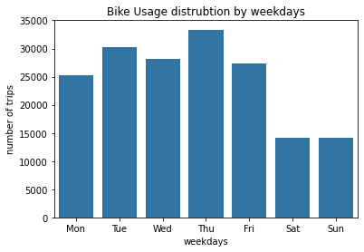

```python
# Check the distrubtion of count of weekdays

# Using the countplot feature from seaborn
# In other to avoid confusion of colours I would using one base colour
# unless there is a need to catergories with colour
# so I will select a base colour

# Weekdays are norminal catergorical varaible, great to be plotted on pie chart but I will settle for
# bar plot because there are 7 days of the week and it would be difficult to understand on a pie plot

base_color = sb.color_palette()[0]

# I would have the weekdays to be arranged accroding to gregorian calendar
weekdays = ["Mon", "Tue", "Wed", "Thu", "Fri", "Sat", "Sun"]

sb.countplot(data = bike_clean, x="start_time_weekday",
             order= weekdays , color=base_color)
plt.xlabel("weekdays")
plt.ylabel("number of trips")
plt.title("Bike Usage distrubtion by weekdays");
```

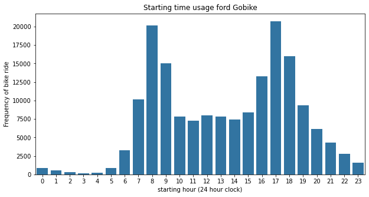

```python
# What hour of the day is the bike most start time,
# this is to say what hour of the day have the most likelihood of people starting a bike ride

# Starting is a discrete variable, bar chart are best suited for it plotting

plt.figure(figsize= [10, 5])
sb.countplot(data= bike_clean, x="start_time_hour", color= base_color)
plt.xlabel("starting hour (24 hour clock)")
plt.ylabel("Frequency of bike ride")
plt.title("Starting time usage ford Gobike");
```

> - The plot above sbows that people are mostly like to start bike rides from the hours of 8am to 9am, suggestive of the fact that they would want to go to work or something, and it declines and peeks at 17:00 or 5pm to 18:00 or 6pm people trend to start riding the bike. This is great but requires further investigation

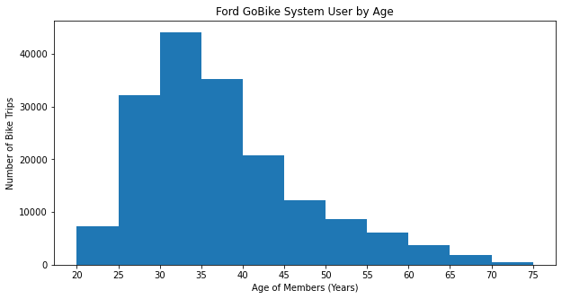

```python
# What is the age distribution of the riders of the bike,
#Age is discrete variable, I would want to use a histogram to see the distribution of ages with 5 years step

plt.figure(figsize= [10, 5])
bin_age = np.arange(20, bike_clean.member_age.max()+5, 5)

tick = [20, 25, 30, 35, 40, 45, 50, 55, 60, 65, 70, 75]
labels = ['{}'. format(i) for i in tick]
plt.hist(data = bike_clean, x="member_age", bins= bin_age)
plt.xticks(tick, labels)

plt.title("Ford GoBike System User by Age")
plt.xlabel('Age of Members (Years)')
plt.ylabel('Number of Bike Trips');
```

> - The histogram shows the majority of users fall between the ages of 25 - 40 years, which is also the same age range of working adults, where 30 to 35 years is have the highest age range.

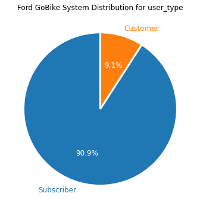

```python
# The distribution of the user type

# User is norminal catergorical variable it would be best ploted with pie chart
fig, ax = plt.subplots(figsize=(10, 5))

user_count = bike_clean.user_type.value_counts()

patches, texts, pcts = ax.pie(
    user_count, labels=user_count.index, autopct='%.1f%%',
    wedgeprops={'linewidth': 3.0, 'edgecolor': 'white'},
    textprops={'size': 'large'},
    startangle=90)
# For each wedge, set the corresponding text label color to the wedge's
# face color.
for i, patch in enumerate(patches):
  texts[i].set_color(patch.get_facecolor())
plt.setp(pcts, color='white')
plt.setp(texts, fontweight=100)
ax.set_title('Ford GoBike System Distribution for user_type')
plt.tight_layout()
```

> - Subscriber user have the 90.9% for all the entire bike rides and Customer users have only 9.1% of the bike ride

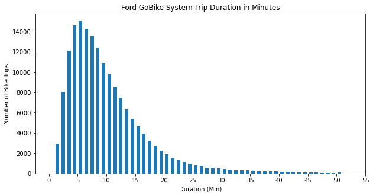

```python
# Duration of the bike rides in MINUTES
# Minutes is discrete varaible although it supposed continuous data approximated bit, so I would use a histogram and put a width

plt.figure(figsize= [10, 5])
bin_mins = np.arange(0, bike_clean.duration_minutes.max(), 1)
ticks = [0, 5, 10, 15, 20, 25, 30,  35, 40, 45, 50, 55]
labels = ['{}'.format(val) for val in ticks]

plt.hist(data = bike_clean, x = 'duration_minutes', bins = bin_mins, rwidth = 0.6)

plt.title("Ford GoBike System Trip Duration in Minutes")
plt.xlabel('Duration (Min)')
plt.xticks(ticks, labels)
plt.ylabel('Number of Bike Trips');
```

> - According to the histogram, the majority of rides last between three and eleven minutes. This shows that riders are traveling short distances on their bikes.

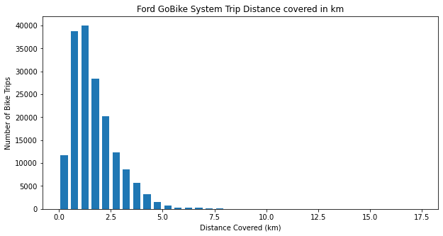

```python
# Distance covered in Km
# Distance is continuous data approximated bit, so I would use a histogram and put a width

plt.figure(figsize= [10, 5])
bin_mins = np.arange(0, bike_clean.distance_km.max()+2, 0.5)


plt.hist(data = bike_clean, x = 'distance_km', bins = bin_mins, rwidth = 0.7)

plt.title("Ford GoBike System Trip Distance covered in km")
plt.xlabel('Distance Covered (km)')
plt.ylabel('Number of Bike Trips');
```

> - Most distances were covered 0.1 to 2.5 km. This shows thar most trips were not long distances. Although there are outlier of long distances covered

```python
gender_counts = bike_clean.member_gender.value_counts()
gender_counts
```

```
Male      128779
Female     40241
Other       3519
Name: member_gender, dtype: int64
```

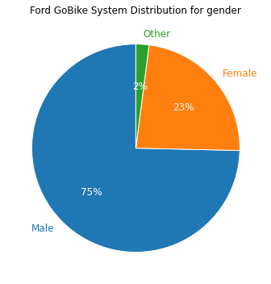

```python
# The distribution of the gender

# Gender is norminal catergorical variable it would be best ploted with pie chart
fig, ax = plt.subplots(figsize=(10, 5))

gender_counts = bike_clean.member_gender.value_counts()

patches, texts, pcts = ax.pie(
    gender_counts, labels=gender_counts.index, autopct='%1.f%%',
    wedgeprops={'edgecolor': 'white'},
    textprops={'size': 'large'},
    startangle=90)
# For each wedge, set the corresponding text label color to the wedge's
# face color.
for i, patch in enumerate(patches):
  texts[i].set_color(patch.get_facecolor())
plt.setp(pcts, color='white')
plt.setp(texts, fontweight=100)
ax.set_title('Ford GoBike System Distribution for gender')
plt.tight_layout()
```

> - The plot shows that lot of male made up the riders in February Ford GoBike Season with 75% of all riders then 23 female and 2% for others

### Discuss the distribution(s) of your variable(s) of interest. Were there any unusual points? Did you need to perform any transformations?

> Fortunately, thanks to meticulous cleaning efforts, the exploratory and visualization phases did not include any major surprises. I had some issues with the length and distance of the bike trip because there were several unexpected outliers.

### Of the features you investigated, were there any unusual distributions? Did you perform any operations on the data to tidy, adjust, or change the form of the data? If so, why did you do this?

> Nothing appears to be unusual for a bike sharing program in a san Francisco. According to the statistics so far, the system's main user base consists of individuals in the typical working age range who utilize the bikes for their everyday journeys.

## Bivariate Exploration

> In this section, I look at the connections and relationship between two variables.

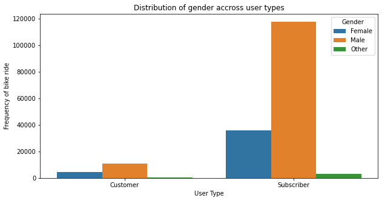

```python
# Want to see the relationship and connection between gender and user type

# Both data are qualitative (Norminal Categorical) data, I would use a cluster bar chart using the seaborn countplot
plt.figure(figsize= [10, 5])

sb.countplot(data = bike_clean, x = 'user_type', hue = 'member_gender')
legend = plt.legend(["Female","Male","Other"])
legend.set_title("Gender")

plt.title("Distribution of gender accross user types")
plt.xlabel("User Type")
plt.ylabel("Frequency of bike ride");
```

> - The Plot shows that there are larger male in subscribed user than male in customer user, where there were little to no other gender aside male and female in customer users

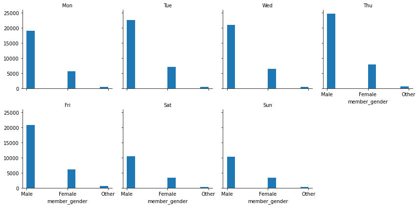

```python
# Let take a look at another catergorical varaible the days of the week and see
# the usage of bike for gender across weekdays

# Gender is a Categorical variable so also week days, here I would love to use Faceting to show this distributions
plt.figure(figsize= [10, 5])
weekdays = ["Mon", "Tue", "Wed", "Thu", "Fri", "Sat", "Sun"]

g = sb.FacetGrid(data = bike_clean, col = "start_time_weekday", col_wrap=4, height= 3, col_order=weekdays);
g.map(plt.hist, "member_gender")
g.set_titles('{col_name}');
```

> - There is a beautiful relationship seen here, as the male usage decrease the female usage decrease. From the week days, Monday had a reduced bike ride for Male, Female and others asides the weekend (Saturday and Sunday)

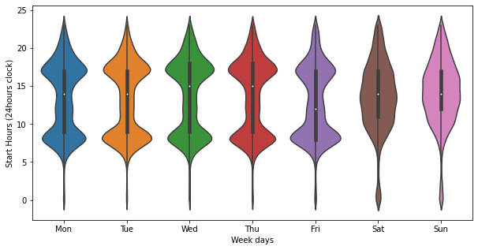

```python
# It would be inhteresting to know the how the start hour in the day is distributed accross the days of the week

# The starting hour is quantitative variable and the days of the week is a qualitative variable,
# I would best plot it using a violin plot
plt.figure(figsize= [10, 5])
weekdays = ["Mon", "Tue", "Wed", "Thu", "Fri", "Sat", "Sun"]

sb.violinplot(data=bike_clean, x="start_time_weekday", y= "start_time_hour", order=weekdays)
plt.xlabel("Week days")
plt.ylabel("Start Hours (24hours clock)");
```

> - This is so beautiful it shows that riders during the work days Mondays to Friday start there ride between the 5 and 10 am in the morning (This suggestive that they ride bikes to work), 3pm and 8 pm in the evening (this is suggestive that the start riding the bike home after close of work). The weekend shows that at people mostly take bike rides between the hours of 10 am and 3pm

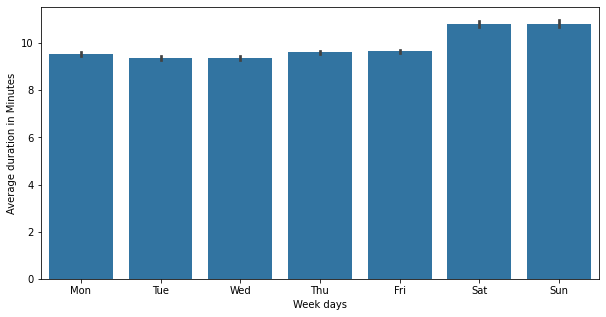

```python
# Next I want to see the average trip duration in minutes per week days

# Week day is a catergorical variable and duration in minutes is quantitative variable
# I will be using a barplot to get the average duration in mintues
plt.figure(figsize= [10, 5])
weekdays = ["Mon", "Tue", "Wed", "Thu", "Fri", "Sat", "Sun"]
sb.barplot(data = bike_clean, x = 'start_time_weekday', y = 'duration_minutes', order= weekdays, color=base_color)

plt.xlabel('Week days')
plt.ylabel('Average duration in Minutes');
```

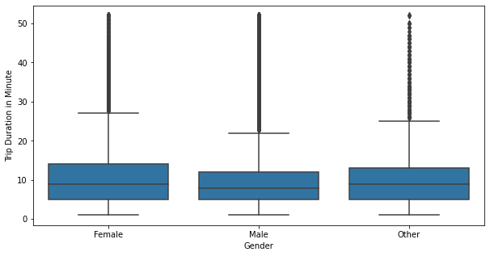

```python
# Now, we will be looking the trip duration distribution vary by gender?

# Gender is a qualitative variable and duration is quantitative
plt.figure(figsize= [10, 5])
sb.boxplot(data=bike_clean, x='member_gender', y='duration_minutes', color=base_color);
plt.xlabel('Gender');
plt.ylabel('Trip Duration in Minute');
```

> - Averagely Female spent more duration on bike than men

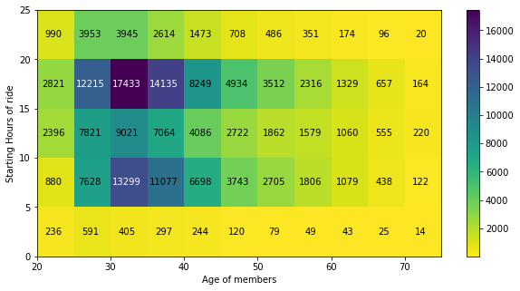

```python
# It would be lovely to know if member_age has any relationship with starting hour  on the ride
# Both age and starting hour are discrete quantitative data, I would be using a heat map

plt.figure(figsize= [10, 5])
#
bins_x = np.arange(20, bike_clean.member_age.max()+5, 5)
bins_y = np.arange(0, bike_clean.start_time_hour.max()+4, 5)

# Use cmin to set a minimum bound of counts
# Use cmap to reverse the color map.
h2d = plt.hist2d(data = bike_clean, x = 'member_age', y = 'start_time_hour',
                 cmin=0.5, cmap='viridis_r', bins = [bins_x, bins_y])

plt.colorbar()
plt.xlabel('Age of members')
plt.ylabel('Starting Hours of ride');

# Select the bi-dimensional histogram, a 2D array of samples x and y.
# Values in x are histogrammed along the first dimension and
# values in y are histogrammed along the second dimension.
counts = h2d[0]

# Add text annotation on each cell
# Loop through the cell counts and add text annotations for each
for i in range(counts.shape[0]):
    for j in range(counts.shape[1]):
        c = counts[i,j]
        if c >= 12000: # increase visibility on darker cells
            plt.text(bins_x[i]+2.20, bins_y[j]+2.5, int(c),
                     ha = 'center', va = 'center', color = 'white')
        elif c > 0:
            plt.text(bins_x[i]+2.20, bins_y[j]+2.5, int(c),
                     ha = 'center', va = 'center', color = 'black')
```

> - There is no partner or linear correlation for the starting hour with the age but from the plot it is intresting to note that 30 to 35 and between the hours of 3 pm to 8pm showed the highest starting hours for the use of bikes

[figure not shown]

```python
# Want to see the relationship and connection between those who used bikre share for all trip and week day

# Both data are qualitative (Categorical) data, I would use a cluster bar
# chart using the seaborn countplot
plt.figure(figsize= [10, 5])

weekdays = ["Mon", "Tue", "Wed", "Thu", "Fri", "Sat", "Sun"]
sb.countplot(data = bike_clean, x = 'start_time_weekday', hue = 'bike_share_for_all_trip',
            order=weekdays)
legend = plt.legend(["Yes","N0"])
legend.set_title("Used Bike for all trip")

plt.title("Distribution Weekdays with which bikes were used for all trip")
plt.xlabel("Week days")
plt.ylabel("Frequency of bike ride for all trip");
```

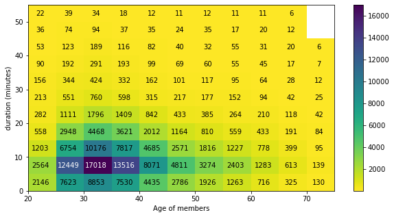

```python
# It would be lovely to know if member_age has any relationship with starting hour  on the ride
# Both age and starting hour are discrete quantitative data, I would be using a heat map

plt.figure(figsize= [10, 5])
#Specifying the bin
bins_x = np.arange(20, bike_clean.member_age.max()+5, 5)
bins_y = np.arange(0, bike_clean.duration_minutes.max()+4, 5)

# Use cmin to set a minimum bound of counts
# Use cmap to reverse the color map.
h2d = plt.hist2d(data = bike_clean, x = 'member_age', y = 'duration_minutes',
                 cmin=0.5, cmap='viridis_r', bins = [bins_x, bins_y])

plt.colorbar()
plt.xlabel('Age of members')
plt.ylabel('duration (minutes)');

# Select the bi-dimensional histogram, a 2D array of samples x and y.
# Values in x are histogrammed along the first dimension and
# values in y are histogrammed along the second dimension.
counts = h2d[0]

# Add text annotation on each cell
# Loop through the cell counts and add text annotations for each
for i in range(counts.shape[0]):
    for j in range(counts.shape[1]):
        c = counts[i,j]
        if c >= 12000: # increase visibility on darker cells
            plt.text(bins_x[i]+2.20, bins_y[j]+2.5, int(c),
                     ha = 'center', va = 'center', color = 'white')
        elif c > 0:
            plt.text(bins_x[i]+2.20, bins_y[j]+2.5, int(c),
                     ha = 'center', va = 'center', color = 'black')
```

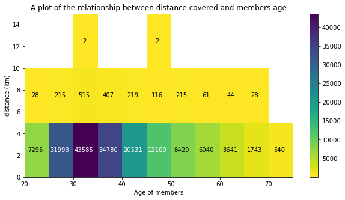

```python
# It would be lovely to know if member_age has any relationship with distance covered on the ride
# Both age and starting hour are discrete quantitative data, I would be using a heat map

plt.figure(figsize= [10, 5])
#Specifying the bin
bins_x = np.arange(20, bike_clean.member_age.max()+5, 5)
bins_y = np.arange(0, bike_clean.distance_km.max()+4, 5)

# Use cmin to set a minimum bound of counts
# Use cmap to reverse the color map.
h2d = plt.hist2d(data = bike_clean, x = 'member_age', y = 'distance_km',
                 cmin=0.5, cmap='viridis_r', bins = [bins_x, bins_y])

plt.colorbar()
plt.xlabel('Age of members')
plt.ylabel('distance (km)')
plt.title("A plot of the relationship between distance covered and members age");

# Select the bi-dimensional histogram, a 2D array of samples x and y.
# Values in x are histogrammed along the first dimension and
# values in y are histogrammed along the second dimension.
counts = h2d[0]

# Add text annotation on each cell
# Loop through the cell counts and add text annotations for each
for i in range(counts.shape[0]):
    for j in range(counts.shape[1]):
        c = counts[i,j]
        if c >= 12000: # increase visibility on darker cells
            plt.text(bins_x[i]+2.20, bins_y[j]+2.5, int(c),
                     ha = 'center', va = 'center', color = 'white')
        elif c > 0:
            plt.text(bins_x[i]+2.20, bins_y[j]+2.5, int(c),
                     ha = 'center', va = 'center', color = 'black')
```

> - This is intresting seeing that majorly between the ages of 25 and 40 are the most active users of the Ford Bike and covered the most distance

## Multivariate Exploration

> To further explore the Ford Go Bike data, I create plot with three or more variables.

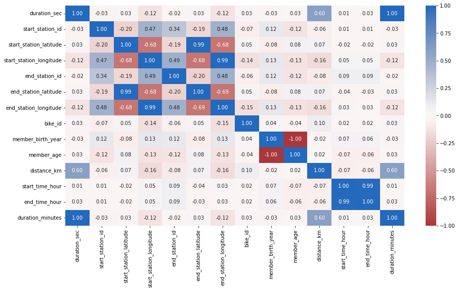

```python
# I will plot Correlation Matrices to see the relationship strength among all the numerical variables
# This is a check to see for some relationships I missed

# Seeing that all values are quantitative I will be using heatmap on a correlation function of the bike_clean data set
plt.figure(figsize= [15, 8])
sb.heatmap(bike_clean.corr(), annot = True,
           fmt = '.2f', cmap = 'vlag_r', center = 0);
```

> - There is a strong correlation between duration in sec and in minutes with distance covered in km,\ Whereas the starting station longitude and lattitude for purposes of machine learning would be great tools to predict ending stations

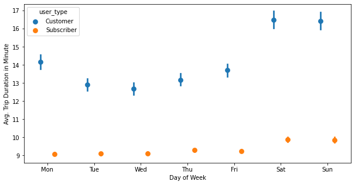

```python
# Now lets see how the average trip duration vary in weekdays between customers and subscribers?
plt.figure(figsize= [10, 5])

weekdays = ["Mon", "Tue", "Wed", "Thu", "Fri", "Sat", "Sun"]
sb.pointplot(data=bike_clean, x='start_time_weekday', y='duration_minutes',
             hue='user_type', dodge=0.3, linestyles="", order=weekdays);
plt.xlabel('Day of Week');
plt.ylabel('Avg. Trip Duration in Minute');
```

> - This is further buttress the point that on weekends people are most likely to spend more time on bike rides and when split into customers and subscriber, customers are spends way wya more time on weekends on bike rides

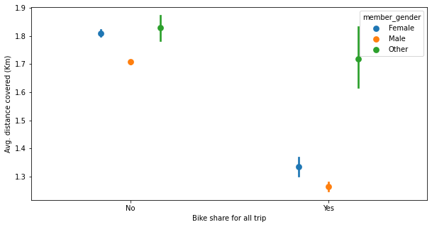

```python
plt.figure(figsize= [10, 5])
sb.pointplot(data=bike_clean, x='bike_share_for_all_trip', y='distance_km',
             hue='member_gender', dodge=0.3, linestyles="", );
plt.xlabel('Bike share for all trip');
plt.ylabel('Avg. distance covered (Km)');
```

### Were there any interesting or surprising interactions between features?

> People who do not use bike to complete all trips cover larger distance in km and other gender category asides male and female shows to cover higher average distance coverage. This is suprising seeing that in the plot of gender and it distribution others have fewer rides, I did not see this coming, it really suprised me